# 18-Evaluation of Prediction/Forecasting Accuracy: Continuous Outcomes

Author

Published

October 23, 2025

# 1 Intro

This is a [Quarto](https://quarto.org) file. Quarto enables you to weave together content and executable code into a finished document. When you execute code within the notebook, the results appear beneath the code. This allows you to share your analyses and results with others so that they can see the results in line with the code for reproducibility. Make sure to have only one sentence per line. To learn more about Quarto see https://quarto.org. For course instructions on using Quarto, see here: https://isaactpetersen.github.io/QuartoBlogFantasyFootball/posts/quarto-instructions/.

# 2 Preamble

## 2.1 Install Libraries

```r
#install.packages("remotes")
#remotes::install_github("DevPsyLab/petersenlab")
#remotes::install_github("FantasyFootballAnalytics/ffanalytics")

#update.packages(ask = FALSE)
```

## 2.2 Load Libraries

```r
library("petersenlab")
library("pROC")
library("magrittr")
library("viridis")
library("viridisLite")
library("msir")
library("tidymodels")
library("tidyverse")
```

## 2.3 Specify Options

```r
options(scipen = 999) # prevent scientific notation
```

## 2.4 Load Data

Load the data file that is in the following location: `./Data/player_stats_weekly.Rdata` (if running locally) or `../Data/player_stats_weekly.Rdata` (if rendering).

```r
load(file = "./Data/player_stats_weekly.RData") # if running locally
load(file = "./Data/players_projections_weekly.RData") # if running locally
load(file = "./Data/nfl_playerIDs.RData") # if running locally
```

```r
load(file = "../Data/player_stats_weekly.RData") # if "rendering" (which uses the Analyses folder as the relative path)
load(file = "../Data/players_projections_weekly.RData") # if "rendering" (which uses the Analyses folder as the relative path)
load(file = "../Data/nfl_playerIDs.RData") # if "rendering" (which uses the Analyses folder as the relative path)
```

## 2.5 Prepare Data

```r
player_stats_weekly_subset <- player_stats_weekly %>%
  filter(!is.na(player_id))

nfl_playerIDs_subset <- nfl_playerIDs %>%
  filter(!is.na(gsis_id)) %>%
  distinct(gsis_id, .keep_all = TRUE) %>% # keep only rows that do not have duplicate values of gsis_id
  select(-all_of(c("team", "position", "height", "weight", "age")))

players_projectedPoints_weekly_combined$season <- as.integer(players_projectedPoints_weekly_combined$season)
players_projections_weekly_average_merged$season <- as.integer(players_projections_weekly_average_merged$season)

player_stats_weekly_subset_IDs <- left_join(
  player_stats_weekly_subset,
  nfl_playerIDs_subset,
  by = c("player_id" = "gsis_id")
) %>%
  filter(!is.na(mfl_id))

projectionsWithActuals_weekly <- full_join(
  player_stats_weekly_subset_IDs,
  players_projectedPoints_weekly_combined,
  by = c("mfl_id" = "id", "season", "week"),
  suffix = c("", "_proj"),
)

crowdAveragedProjectionsWithActuals_weekly <- full_join(
  player_stats_weekly_subset_IDs,
  players_projections_weekly_average_merged,
  by = c("mfl_id" = "id", "season", "week"),
  suffix = c("", "_proj"),
)

projectionsWithActuals_weekly <- projectionsWithActuals_weekly %>%
  unite(
    "player_id_season_week",
    player_id,
    season,
    week,
    remove = FALSE
  )

crowdAveragedProjectionsWithActuals_weekly <- crowdAveragedProjectionsWithActuals_weekly %>%
  unite(
    "player_id_season_week",
    player_id,
    season,
    week,
    remove = FALSE
  )
```

# 3 Predicting WR Fantasy Points

We will use crowd-averaged projections to predict Wide Receivers’ fantasy points. First, we prepare the data:

```r
projectionsWithActuals_weekly_wr <- projectionsWithActuals_weekly %>%
  filter(position == "WR")

crowdAveragedProjectionsWithActuals_weekly_wr <- crowdAveragedProjectionsWithActuals_weekly %>%
  filter(position == "WR")
```

## 3.1 Accuracy Indices

### 3.1.1 Individual Sources of Projections

Provide the accuracy indices for predicting Wide Receivers’ fantasy points (`fantasyPoints`) from individual sources of projections of their fantasy points for that week (`raw_points`):

```r
petersenlab::accuracyOverall(
  predicted = projectionsWithActuals_weekly_wr$fantasyPoints, # predictor variable
  actual = projectionsWithActuals_weekly_wr$raw_points, # outcome variable
  dropUndefined = TRUE
)
```

```
         ME      MAE MdAE      MSE     RMSE       MPE     MAPE    sMAPE
1 0.6145695 4.863468 3.52 44.82737 6.695325 -42.76035 117.2919 37.56612
      MASE     RMSLE   rsquared rsquaredAsPredictor rsquaredAdjAsPredictor
1 1.162314 0.8073974 -0.7881229           0.3139983              0.3139455
  rsquaredPredictiveAsPredictor
1                     0.3137823
```

### 3.1.2 Crowd-Averaged Projections

Provide the accuracy indices for predicting Wide Receivers’ fantasy points (`fantasyPoints`) from crowd-averaged projections of their fantasy points for that week (`points`):

```r
petersenlab::accuracyOverall(
  predicted = crowdAveragedProjectionsWithActuals_weekly_wr$fantasyPoints, # predictor variable
  actual = crowdAveragedProjectionsWithActuals_weekly_wr$points, # outcome variable
  dropUndefined = TRUE
)
```

```
         ME      MAE     MdAE      MSE     RMSE       MPE     MAPE    sMAPE
1 0.6343308 4.439692 2.983829 39.33556 6.271807 -36.75057 100.5594 39.99373
    MASE     RMSLE   rsquared rsquaredAsPredictor rsquaredAdjAsPredictor
1 1.0416 0.7938017 -0.5595843            0.374357              0.3742538
  rsquaredPredictiveAsPredictor
1                     0.3739209
```

Which projections were more accurate according to $R^2$ and mean absolute error (MAE): individual sources of projections or crowd-averaged projections? What percent of the variance did the projections explain? Did they explain more or less than 50% of the variance? Based on that, how accurate would you say the projections are?

## 3.2 Calibration Plot

### 3.2.1 Individual Sources of Projections

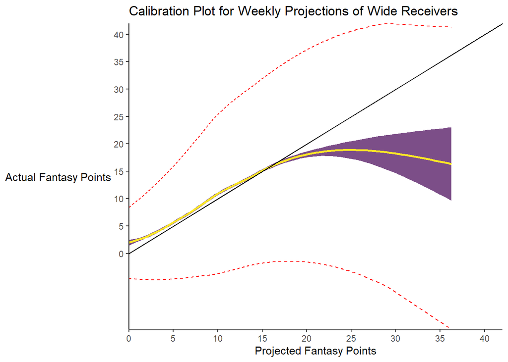

```r
#95 prediction interval based on LOESS model
calibrationLoessModel1 <- msir::loess.sd(
  x = projectionsWithActuals_weekly_wr$raw_points,
  y = projectionsWithActuals_weekly_wr$fantasyPoints,
  nsigma = qnorm(.975),
  na.action = "na.exclude")

calibrationLoessPredictionInterval1 <- data.frame(
  x = calibrationLoessModel1$x,
  y = calibrationLoessModel1$y,
  lower = calibrationLoessModel1$lower,
  upper = calibrationLoessModel1$upper)

plotRangeMin1 <- min(calibrationLoessModel1$lower, na.rm = TRUE)

plotRangeMax1 <- max(calibrationLoessModel1$upper, na.rm = TRUE)

ggplot2::ggplot(
  data = projectionsWithActuals_weekly_wr,
  aes(
    x = raw_points,
    y = fantasyPoints)) +
  coord_cartesian(
    xlim = c(0, plotRangeMax1),
    ylim = c(plotRangeMin1, plotRangeMax1),
    expand = FALSE) +
  scale_x_continuous(breaks = seq(0, plotRangeMax1, by = 5)) +
  scale_y_continuous(breaks = seq(0, plotRangeMax1, by = 5)) +
  geom_line(
    data = calibrationLoessPredictionInterval1,
    aes(
      x = x,
      y = lower),
    color = "red",
    linetype = "dashed") + #Lower estimate of 95% prediction interval of linear model
  geom_line(
    data = calibrationLoessPredictionInterval1,
    aes(
      x = x,
      y = upper),
    color = "red",
    linetype = "dashed") + #Upper estimate of 95% prediction interval of linear model
  geom_smooth(
    method = "gam",
    color = viridisLite::viridis(3)[3],
    fill = viridisLite::viridis(3)[1],
    alpha = 0.7) + #95% confidence interval of GAM model
  geom_abline(
    slope = 1,
    intercept = 0) +
  labs(
    x = "Projected Fantasy Points",
    y = "Actual Fantasy Points",
    title = "Calibration Plot for Weekly Projections of Wide Receivers"
  ) +
  theme_classic() +
  theme(axis.title.y = element_text(angle = 0, vjust = 0.5)) # horizontal y-axis title
```

Are the projections calibrated? Describe any miscalibration.

### 3.2.2 Crowd-Averaged Projections

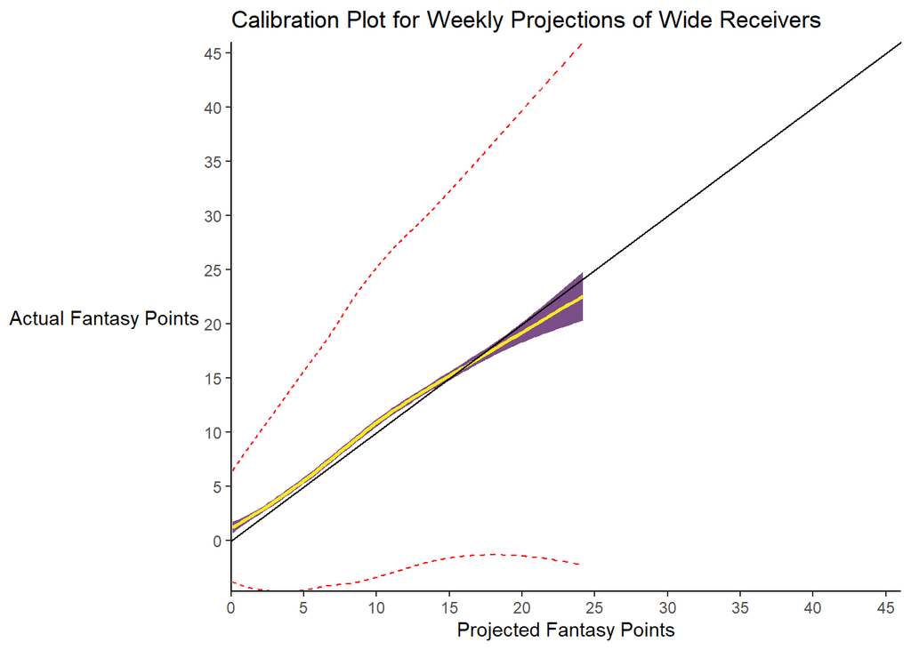

```r
#95 prediction interval based on LOESS model
calibrationLoessModel2 <- msir::loess.sd(
  x = crowdAveragedProjectionsWithActuals_weekly_wr$points,
  y = crowdAveragedProjectionsWithActuals_weekly_wr$fantasyPoints,
  nsigma = qnorm(.975),
  na.action = "na.exclude")

calibrationLoessPredictionInterval2 <- data.frame(
  x = calibrationLoessModel2$x,
  y = calibrationLoessModel2$y,
  lower = calibrationLoessModel2$lower,
  upper = calibrationLoessModel2$upper)

plotRangeMin2 <- min(calibrationLoessModel2$lower, na.rm = TRUE)

plotRangeMax2 <- max(calibrationLoessModel2$upper, na.rm = TRUE)

ggplot2::ggplot(
  data = crowdAveragedProjectionsWithActuals_weekly_wr,
  aes(
    x = points,
    y = fantasyPoints)) +
  coord_cartesian(
    xlim = c(0, plotRangeMax2),
    ylim = c(plotRangeMin2, plotRangeMax2),
    expand = FALSE) +
  scale_x_continuous(breaks = seq(0, plotRangeMax2, by = 5)) +
  scale_y_continuous(breaks = seq(0, plotRangeMax2, by = 5)) +
  geom_line(
    data = calibrationLoessPredictionInterval2,
    aes(
      x = x,
      y = lower),
    color = "red",
    linetype = "dashed") + #Lower estimate of 95% prediction interval of linear model
  geom_line(
    data = calibrationLoessPredictionInterval2,
    aes(
      x = x,
      y = upper),
    color = "red",
    linetype = "dashed") + #Upper estimate of 95% prediction interval of linear model
  geom_smooth(
    method = "gam",
    color = viridisLite::viridis(3)[3],
    fill = viridisLite::viridis(3)[1],
    alpha = 0.7) + #95% confidence interval of GAM model
  geom_abline(
    slope = 1,
    intercept = 0) +
  labs(
    x = "Projected Fantasy Points",
    y = "Actual Fantasy Points",
    title = "Calibration Plot for Weekly Projections of Wide Receivers"
  ) +
  theme_classic() +
  theme(axis.title.y = element_text(angle = 0, vjust = 0.5)) # horizontal y-axis title
```

Which show better calibration: the individual sources of projections or the crowd-averaged projections? Based on all of the available evidence, which would you say is more accurate (and why)?